# IMDB ANN

Rita Koranyi

11/19/2020

## Loading the Packages

For the neural network method we use the `nnet` package (and `gamlss.add` to plot these networks) and `ggplot2` to create some plots, furthermore the `caret` for cross-validation.

## Loading the Data

and let’s have a look a the structure.

```r
str(IMDB)
```

[output not shown]

## A first look at the Data

We trained a neural network to classify, if a movie will be profitable or not. As an input for our network we chose seven variables: * Color: whether the film was black and white or color * Director Facebook Likes: number of likes on the director’s facebook page * Actor 1 Facebook Likes: number of likes on the director’s facebook page * Cast Total Facebook Likes: the sum of facebook likes of the film cast members * Number of User Reviews: how many users reviewed the movie on IMDB * IMDB Score: the IMDB score of the movie * Movie Facebook Likes: number of likes of the movie on facebook

We excluded the missing values for the color, as missing values cannot be meanful replaced. For the other variables the missing values have been replaced with the mean value of the given variable. In this way, data loss was prevented. The numeric values have been normalized in order to bring all the numerical variables to the same range.

## Prepare Data for training

The data is being splitted with the following ratio: 80% of the data for training and 20% for testing the our network.

```
## [1] 0.7969674
```

## The Neural Network

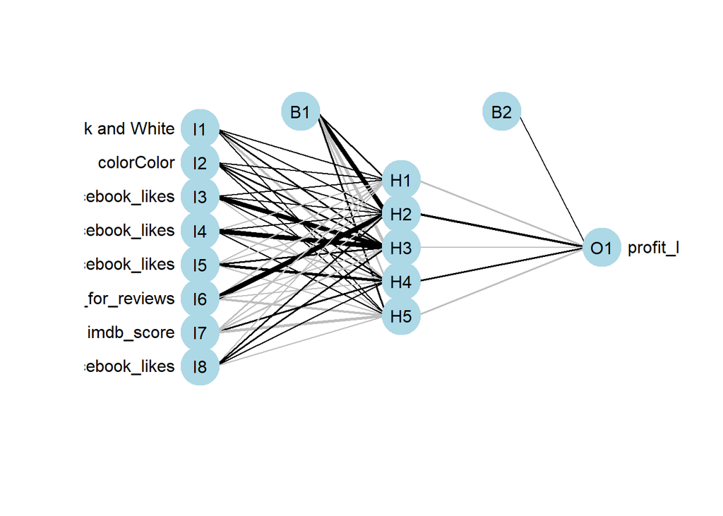

```
## a 8-5-1 network with 51 weights
## inputs: color Black and White colorColor director_facebook_likes actor_1_facebook_likes cast_total_facebook_likes num_user_for_reviews imdb_score movie_facebook_likes
## output(s): profit_loss
## options were - entropy fitting  decay=5e-04
```

## Make Predictions

Let’s see how our network classifies performs. Loss-Loss and Profit-Profit values show how many times were the movies correctly assessed by our network, Loss-Profit and Profit-Loss show how many times were the films incorrectly classified.

[output not shown]

The accuracy of the network:

```
## [1] 0.6434447
```

```
## [1] 0.6247934
```

Or do all of it using the `confusionMatrix` function

```
## Confusion Matrix and Statistics
##
##           Reference
## Prediction Loss Profit
##     Loss   1134    706
##     Profit  681   1369
##
##                Accuracy : 0.6434
##                  95% CI : (0.6282, 0.6585)
##     No Information Rate : 0.5334
##     P-Value [Acc > NIR] : <2e-16
##
##                   Kappa : 0.2843
##
##  Mcnemar's Test P-Value : 0.5193
##
##             Sensitivity : 0.6248
##             Specificity : 0.6598
##          Pos Pred Value : 0.6163
##          Neg Pred Value : 0.6678
##              Prevalence : 0.4666
##          Detection Rate : 0.2915
##    Detection Prevalence : 0.4730
##       Balanced Accuracy : 0.6423
##
##        'Positive' Class : Loss
##
```

## ROC Curves

The Receiver Operating Characteristic is a useful tool to indicate model quality. For this we plot sensitivity against 1-specificity

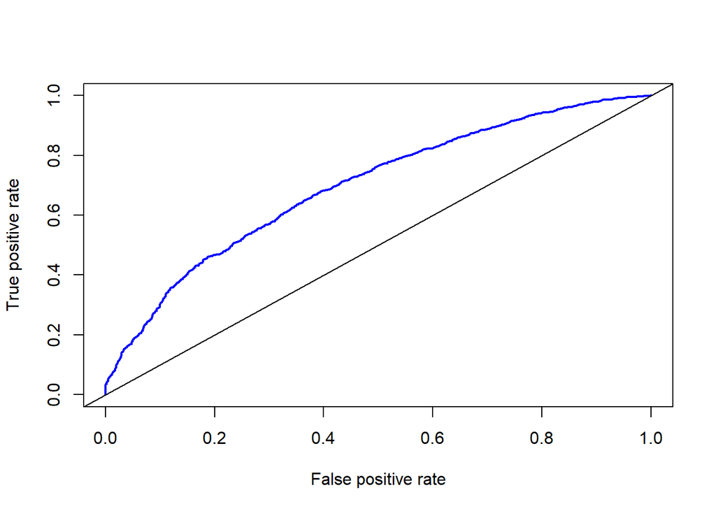

```r
set.seed(123)
tuGrid <- expand.grid(size = seq(from = 1, to = 5, by = 1), decay = seq(from = 0.1, to = 0.5, by = 0.1))

trCtrl <- trainControl(
  method = 'repeatedcv',
  number = 10,
  repeats = 5,
  returnResamp = 'final'
)

models_movies <- train(profit_loss ~., data= movies_df2 ,
  method = 'nnet', metric = 'Accuracy',
  linear.output = FALSE,
    tuneGrid = tuGrid,
  trControl = trCtrl
)
#
# fitControl <- trainControl(method = "repeatedcv",
#                            number = 10,
#                            repeats = 5,
#                            classProbs = TRUE,
#                            summaryFunction = twoClassSummary)
#
# nnetGrid <-  expand.grid(size = seq(from = 1, to = 10, by = 1),
#                         decay = seq(from = 0.1, to = 0.5, by = 0.1))
#
# nnetFit <- train(profit_loss ~., data= movies_df2,
#                  method = "nnet",
#                  metric = "Accuracy",
#                  trControl = fitControl,
#                  tuneGrid = nnetGrid,
#                  verbose = FALSE)
```

```
## Neural Network
##
## 3891 samples
##    7 predictor
##    2 classes: 'Loss', 'Profit'
##
## No pre-processing
## Resampling: Cross-Validated (10 fold, repeated 5 times)
## Summary of sample sizes: 3502, 3502, 3502, 3502, 3502, 3502, ...
## Resampling results across tuning parameters:
##
##   size  decay  Accuracy   Kappa
##   1     0.1    0.6317632  0.2649447
##   1     0.2    0.6305297  0.2621462
##   1     0.3    0.6292451  0.2587903
```

[output cut: 25 more lines]

```
## a 8-4-1 network with 41 weights
## inputs: `color Black and White` colorColor director_facebook_likes actor_1_facebook_likes cast_total_facebook_likes num_user_for_reviews imdb_score movie_facebook_likes
## output(s): .outcome
## options were - entropy fitting  decay=0.1
```